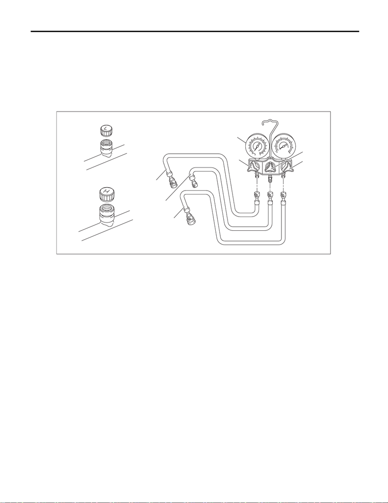

AC-27

Refrigerant Charging Procedure

HVAC SYSTEM (HEATER, VENTILATOR AND A/C)

5. Refrigerant Charging Procedure

A: PROCEDURE

CAUTION:

• While working, be sure to wear protective goggles and protective gloves.

• Air in the cycle can cause insufficient air conditioning, and water in the cycle can cause clogging

in the cycle (icing) and rust. To remove this air and water content, use a vacuum pump to perform

evacuation before filling with refrigerant. By making the inside of the cycle a vacuum, the water con-

tent will evaporate even at normal temperatures, and can be removed.

1) Attach the manifold gauge set.

Preparation tool:

Manifold gauge set

(1) Check that all valves are fully closed.

(2) Install the low/high pressure hoses to the service ports on the low/high pressure sides of the vehicle

respectively.

CAUTION:

Confirm that the connections are secure.

(3) Connect the center manifold hose of the manifold gauge to the vacuum pump.

Preparation tool:

Vacuum pump

2) Perform evacuation.

CAUTION:

Make sure to perform evacuation using a vacuum pump.

(1) Open the low-pressure valve, high-pressure valve and center valve.

(2) Operate the vacuum pump.

(3) Perform evacuation for 5 minutes or more, and when the low pressure gauge needle reaches -0.1

MPa (-1.0 kgf/cm

, –14 psi), close the center manifold hose valve, and stop the vacuum pump.

(1) Manifold gauge (4) High pressure valve (7) High-pressure hose

(2) Low pressure valve (5) Low-pressure hose (8) Low-pressure side service port

(3) Center valve (6) Center manifold hose (vacuum

pump and charge)

(9) High-pressure side service port

AC-02425

(8)

LO HI

(2)

(4)

(3)

(1)

(6)

(7)

(5)

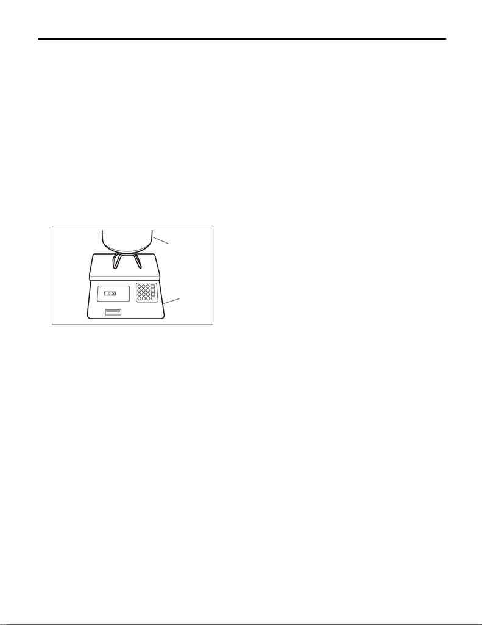

AC-28

Refrigerant Charging Procedure

HVAC SYSTEM (HEATER, VENTILATOR AND A/C)

(4) Leave alone for 5 to 10 minutes after closing the low pressure side and high pressure side valves, and

check whether there is any change in the low pressure gauge needle indication.

If the needle position changes, this indicates a leak. Check the pipe and hose connections, and repair the

location with the problem.

After repair, retry charging the refrigerant from the step 1).

(5) If there is no leakage, continue evacuation for additional 20 — 30 minutes, close all valves and then

stop the vacuum pump.

3) Charge refrigerant.

(1) Follow the can tap operation manual to attach it to the refrigerant can.

Preparation tool:

Can tap

(2) Disconnect the center manifold hose from the vacuum pump, and connect the hose to the tap valve.

Preparation tool:

Weight scale

NOTE:

When 13.6 kg (30 lb) refrigerant container (1) is used, measure the amount of refrigerant with a refrigerant

charging scale (2), and connect with the center manifold hose.

(3) Open the tap valve of HFC-134a supply container (refrigerant can or refrigerant container).

(4) Loosen the center manifold hose connection on the manifold gauge for a few seconds (if there is a

purge valve on the manifold gauge, push this instead) to allow the air in the center manifold hose to be

bled by the refrigerant pressure.

(5) Open the low-pressure side and high-pressure side valves of the manifold gauge to fill with refrigerant.

NOTE:

If the HFC-134a supply container is empty, close all manifold gauge valves and the tap valve of HFC-134a

supply container, and replace the empty supply container with a new one. After replacing with a new HFC-

134a supply container, perform air purge, and resume the filling operation.

(6) If the low pressure gauge indicates approximately 0.2 MPa (2.0 kgf/cm

, 29 psi) or refrigerant filling ef-

ficiency drops, close the low-pressure side valve and high-pressure side valve.

(7) Check that the low-pressure side valve and high-pressure side valve are closed, turn off the A/C

switch and start the engine.

CAUTION:

When filling with the engine running, do not open the high pressure side valve. Always fill from the

low pressure side.

(8) To prevent damage to the compressor, push the A/C switch ON-OFF quickly a few times.

AC-00215

(1)

(2)

[figure not shown]

AC-29

Refrigerant Charging Procedure

HVAC SYSTEM (HEATER, VENTILATOR AND A/C)

(9) Set the vehicle to the following conditions.

(10) Open the low-pressure side valve, check the refrigerant pressure with a manifold gauge and fill with

refrigerant up to the specified amount. <Ref. to AC-23, INSPECTION WITH PRESSURE SYMPTOMS,

INSPECTION, Refrigerant Pressure with Manifold Gauge Set.>

4) Using an electronic leak detector (leak tester), check for refrigerant leaks in the system. <Ref. to AC-30,

INSPECTION, Refrigerant Leak Check.>

5) After filling with refrigerant, close all valves and remove the manifold gauge set.

6) Attach cap to the service port of the low-pressure side and high-pressure side.

Item Condition

Engine speed 1,500 r/min

A/C switch ON

Temperature adjustment dial LO (MAX COOL)

Fan dial HI (MAX)

FRESH/RECIRC switch RECIRC

Air flow control dial or switch VENT

Window OPEN